# data-code-1

```
Warning message:
“There was 1 warning in `mutate()`.
ℹ In argument: `expansion_year = year(mdy(date_str))`.
Caused by warning:
!  10 failed to parse.”
```

### Question 1: Provide a table of mean hospital uncompensated care (in millions of dollars) by year, from 2010 through 2018. How has uncompensated care changed over time?

```
[1] "Table 1: Mean Hospital Uncompensated Care (2010-2018)"
```

A tibble: 9 × 2

| Year <dbl> | Mean Uncompensated Care ($ Millions) <dbl> |
| --- | --- |
| 2010 | 9.79 |
| 2011 | 5.33 |
| 2012 | 5.63 |
| 2013 | 6.07 |
| 2014 | 4.80 |
| 2015 | 3.86 |
| 2016 | 4.13 |
| 2017 | 4.93 |
| 2018 | 4.96 |

### Question 2: Plot mean uncompensated care over time separately for states that expanded Medicaid in 2014 versus states that never expanded. Drop all states that expanded after 2014. Does the graph suggest a potential treatment effect?

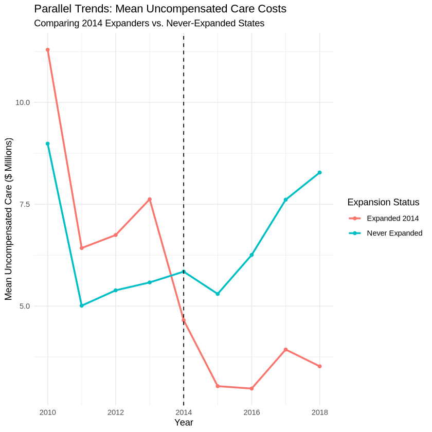

### Question 3: Using 2012 and 2015 as your pre and post periods, present a 2x2 DD table of mean uncompensated care for expansion versus non-expansion states.

A tibble: 2 × 3

| group <chr> | Post (2015) <dbl> | Pre (2012) <dbl> |
| --- | --- | --- |
| Expanded 2014 | 3.03 | 6.75 |
| Never Expanded | 5.30 | 5.39 |

### Question 5: Estimate the effect of Medicaid expansion on hospital uncompensated care using a standard DD regression estimator, focusing only on states that expanded in 2014 versus those that never expanded.

```
Call:
lm(formula = uncomp_millions ~ treat + post + treat:post, data = reg_data)

Residuals:
   Min     1Q Median     3Q    Max
 -13.9   -5.9   -3.5   -1.1 4152.9

Coefficients:
                   Estimate Std. Error t value Pr(>|t|)
(Intercept)          6.0295     0.5948  10.138  < 2e-16 ***
treatTRUE            1.6465     0.7621   2.161   0.0307 *
postTRUE             0.6350     0.7843   0.810   0.4181
treatTRUE:postTRUE  -4.6839     1.0028  -4.671 3.02e-06 ***
---
Signif. codes:  0 ‘***’ 0.001 ‘**’ 0.01 ‘*’ 0.05 ‘.’ 0.1 ‘ ’ 1

Residual standard error: 40.3 on 27877 degrees of freedom
  (12960 observations deleted due to missingness)
Multiple R-squared:  0.001694,	Adjusted R-squared:  0.001587
F-statistic: 15.77 on 3 and 27877 DF,  p-value: 3.049e-10
```

### Question 6: Include hospital and year fixed effects in your estimates using the fixest package. Cluster your standard errors at the state level. How do your results compare to those in question 5?

```
NOTES: 12,960 observations removed because of NA values (LHS: 12,960).
       116/0 fixed-effect singletons were removed (116 observations).
```

```
OLS estimation, Dep. Var.: uncomp_millions
Observations: 27,765
Fixed-effects: provider_number: 3,584,  year: 9
Standard-errors: Clustered (state)
           Estimate Std. Error  t value  Pr(>|t|)
expandTRUE -5.09591    1.74597 -2.91868 0.0058777 **
---
Signif. codes:  0 '***' 0.001 '**' 0.01 '*' 0.05 '.' 0.1 ' ' 1
RMSE: 30.3     Adj. R2: 0.353749
             Within R2: 0.001555
```

### Question 7: Repeat the analysis in question 6 but include all states (even those that expanded after 2014). Are your results different? If so, why?

```
NOTES: 17,715 observations removed because of NA values (LHS: 17,715).
       166/0 fixed-effect singletons were removed (166 observations).
```

```
OLS estimation, Dep. Var.: uncomp_millions
Observations: 36,856
Fixed-effects: provider_number: 4,764,  year: 9
Standard-errors: Clustered (state)
           Estimate Std. Error  t value  Pr(>|t|)
expandTRUE -4.18838    1.37135 -3.05421 0.0035537 **
---
Signif. codes:  0 '***' 0.001 '**' 0.01 '*' 0.05 '.' 0.1 ' ' 1
RMSE: 26.6     Adj. R2: 0.359461
             Within R2: 0.001563
```

### Question 8: Provide an “event study” graph showing the effects of Medicaid expansion in each year.

```
NOTES: 12,960 observations removed because of NA values (LHS: 12,960).
       116/0 fixed-effect singletons were removed (116 observations).
```

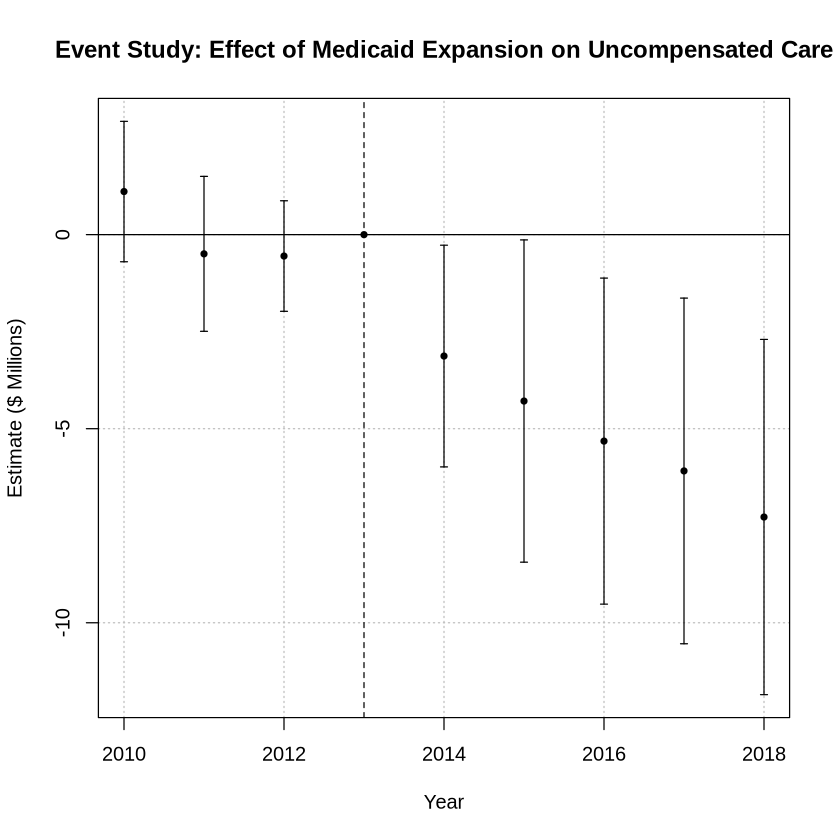

### Question 9: Repeat part 8 but include all states that expanded after 2014. You will need to construct an “event time” variable and bin end points as discussed in class.

```
NOTES: 28,518 observations removed because of NA values (LHS: 17,715, RHS: 16,626).
       104/0 fixed-effect singletons were removed (104 observations).
```

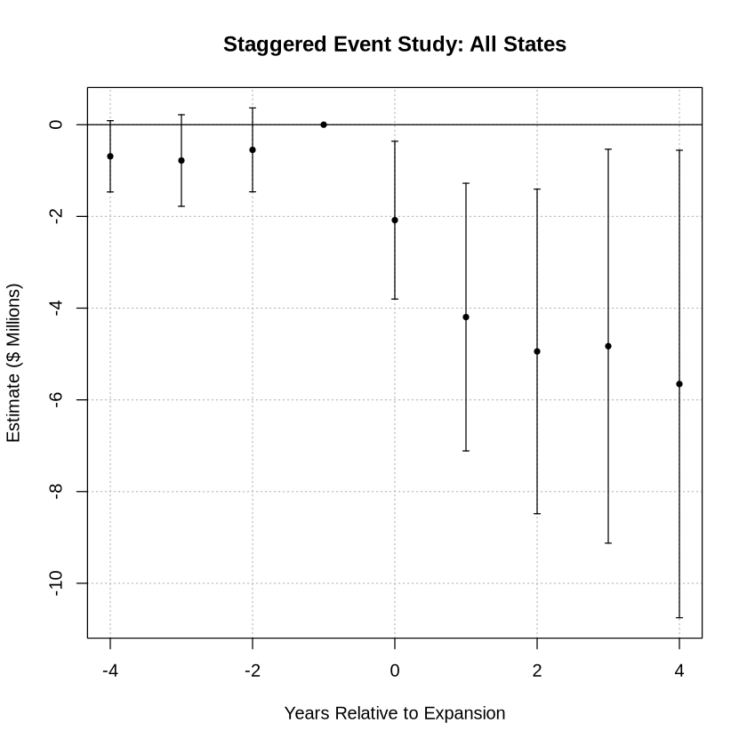

### Question 10: Summarize your findings from questions 5-9. What is the effect of Medicaid expansion on hospital uncompensated care? Do the event study graphs suggest any concerns about the parallel trends assumption? Briefly discuss one limitation of the standard TWFE estimator in the context of staggered Medicaid expansion.

Medicaid expansion effectively reduced the financial burden on hospitals. Event studies (Q8 & 9) confirm the research design is valid by showing parallel pre-trends. However, because expansion was staggered over many years, the standard TWFE might slightly underestimate the true effect due to the weighting issues that come up when comparing early-adopters to late-adopters.